# LatentClass_Analysis

Akshay Ratnawat

2/6/2021

# Latent Class Analysis in German Credit DataSet

### Importing the data

```r
data = read.csv("C:\\Users\\aksha\\OneDrive\\Desktop\\Files\\Courses\\Data Mining\\Lecture_3\\Assignment_3\\german_credit_data.csv")

# Selecting the Categorical Variables
myvars = c("Sex", "Job", "Housing", "Saving.accounts", "Checking.account", "Purpose")
newdata = data[myvars]
head(newdata)
```

```
##      Sex Job Housing Saving.accounts Checking.account             Purpose
## 1   male   2     own            <NA>           little            radio/TV
## 2 female   2     own          little         moderate            radio/TV
## 3   male   1     own          little             <NA>           education
## 4   male   2    free          little           little furniture/equipment
## 5   male   2    free          little           little                 car
## 6   male   1    free            <NA>             <NA>           education
```

### Visualizing the data

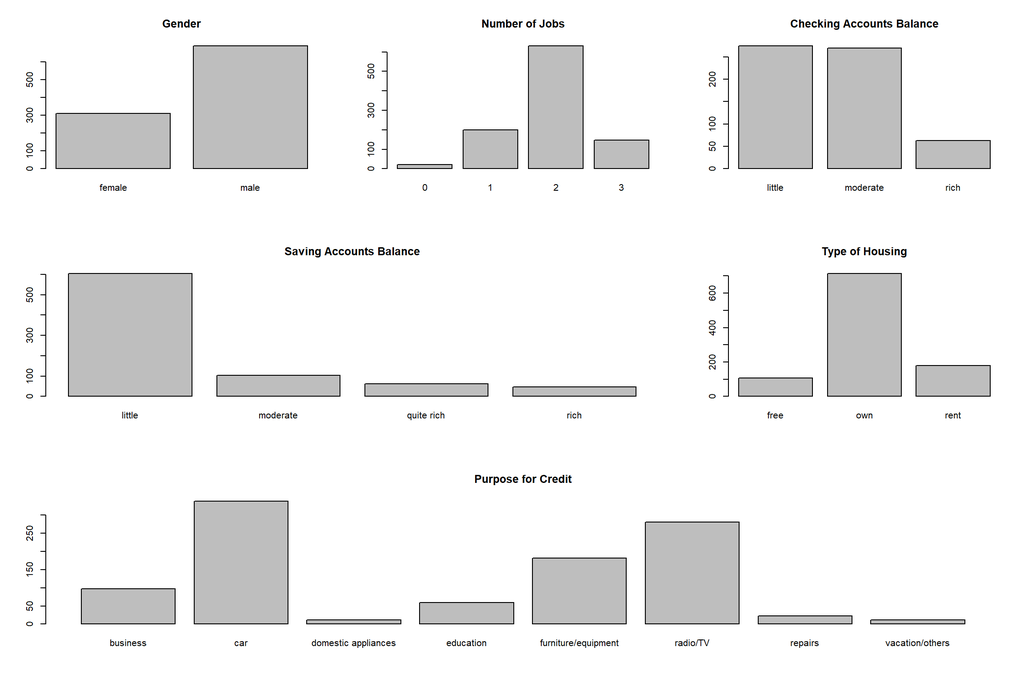

```r
layout(matrix(c(1,2,3,
                4,4,5,
                6,6,6), nrow = 3, ncol =3,  byrow = TRUE))

barplot(table(newdata$Sex), main="Gender")
barplot(table(newdata$Job), main="Number of Jobs")
barplot(table(newdata$Checking.account), main="Checking Accounts Balance")
barplot(table(newdata$Saving.accounts), main="Saving Accounts Balance")
barplot(table(newdata$Housing), main="Type of Housing")
barplot(table(newdata$Purpose), main="Purpose for Credit")
```

The overall profile of the German Credit Portfolio is as follows:

1. Majority of Male population.
2. Majority have two jobs.
3. Low Savings Account Balance
4. Little to Moderate Checking Account Balance
5. Majority of the credit is for Durable consumer Goods such as car, Radio, TV. Credit for productive uses is quite less.

### Converting the Categorical Data into Numerical Format

```r
# Replacing all the Missing values with NA
newdata[is.na(newdata)] <- "NA"
```

```r
unclassed_data = as.data.frame(data.matrix(data.frame(unclass(newdata))))
colnames(unclassed_data) <- c("Sex_Class", "Job_Class","Housing_Class","Savings.accounts_Class","Checking.account_Class",
                              "Purpose_Class")
```

### Dividing into Training and test Data

```r
## 75% of the sample size
smp_size <- floor(0.70 * nrow(unclassed_data))

## set the seed to make your partition reproducible
set.seed(123)
train_ind <- sample(seq_len(nrow(unclassed_data)), size = smp_size)

train <- unclassed_data[train_ind, ]
test <- unclassed_data[-train_ind, ]

# Checking the Dimension of the data frame
dim.data.frame(train)
```

```
## [1] 700   6
```

```r
dim.data.frame(test)
```

```
## [1] 300   6
```

### Running the Lazarsfeld’s Latent Class Analysis

```r
library(poLCA)
f = cbind(Sex_Class, Housing_Class, Savings.accounts_Class, Purpose_Class,Checking.account_Class )~1

# Creating Data Frames to Store the AIC and BIC
AIC <- data.frame()
BIC <- data.frame()

#Running LCA for clusters 2 to 6
for(i in 2:6){
              #Run LCA for each level of i, allowing up to 6 iterations
              lca <- poLCA(f, train, nclass=i, tol=.001, nrep=20, verbose=FALSE)

              #Combine LCA results AIC and BIC, write to dataframe
              AIC<- rbind(AIC, cbind(i, (lca$aic)))
              BIC<-rbind(BIC, cbind(i, (lca$bic)))
              }

# Combining the AIC and BIC
results = cbind(AIC, BIC$V2)
names(results) =  c("Classes","AIC","BIC")
results = data.frame(results)
results
```

```
##   Classes      AIC      BIC
## 1       2 7555.194 7714.482
## 2       3 7532.838 7774.045
## 3       4 7514.535 7837.662
## 4       5 7508.405 7913.451
## 5       6 7518.274 8005.240
```

### Plotting the AIC and BIC information

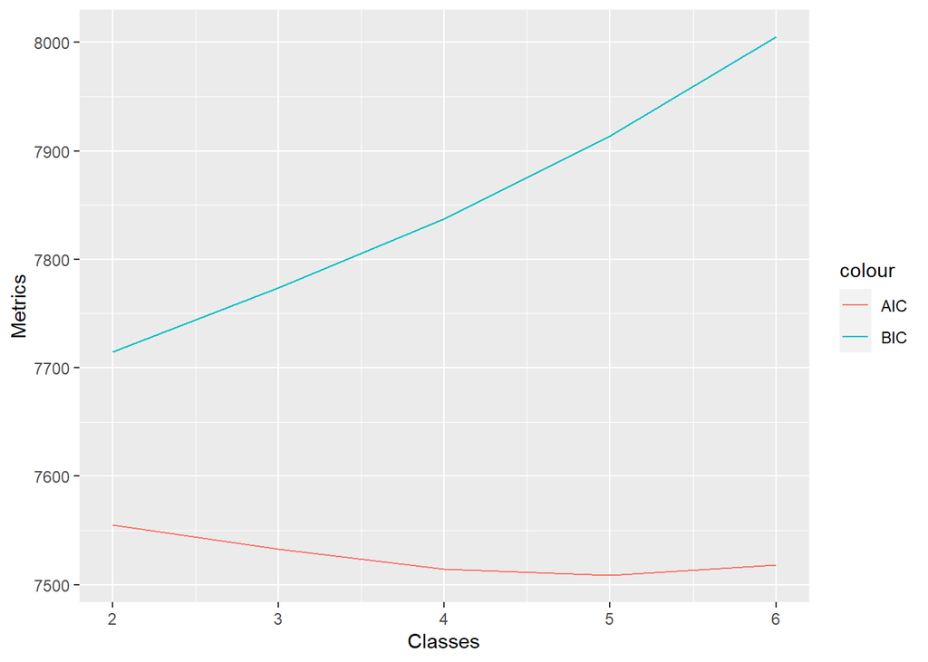

```r
library(ggplot2)
ggplot(results, aes(Classes)) +
  geom_line(aes(y = AIC, colour = "AIC")) +
  geom_line(aes(y = BIC, colour = "BIC")) +
  labs(y = "Metrics")
```

From above it seems we should choose 3 class for classification because: 1. A model with lower AIC is better which gives us 5 classes 2. A model with lower BIC is better which gives us 2 classes. 3. Thus we have a tradeoff between a lower AIC and a lower BIC because as AIC falls BIC rises. 4. Thus a better number of class would be 3 classes.

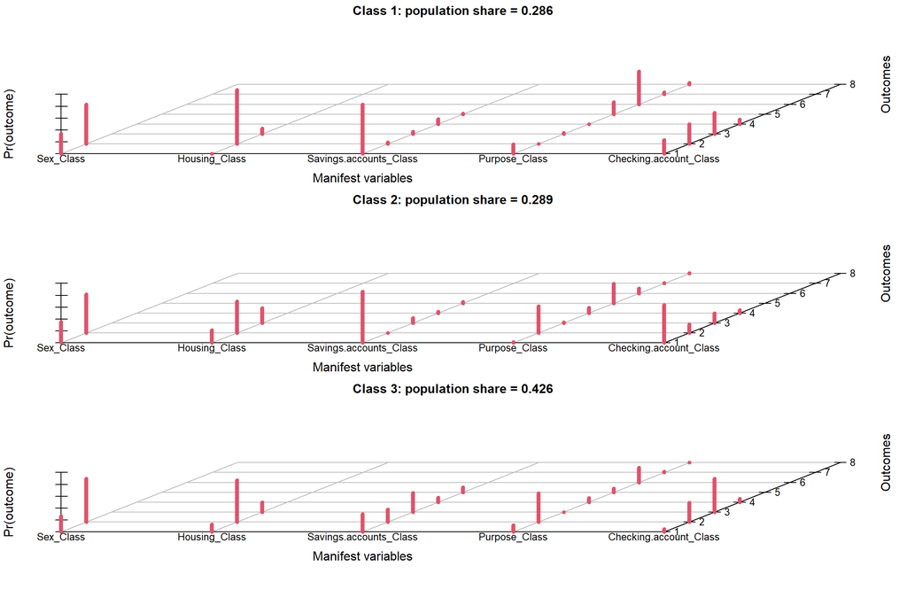

```r
lca_3class <- poLCA(f, train, nclass=3, tol=.001, nrep=20, verbose=FALSE, graphs =TRUE)
```

Printing the Probabilities

```r
lca_3class$probs
```

```
## $Sex_Class
##               Pr(1)     Pr(2)
## class 1:  0.3387847 0.6612153
## class 2:  0.3503755 0.6496245
## class 3:  0.2666679 0.7333321
##
## $Housing_Class
##                  Pr(1)     Pr(2)      Pr(3)
## class 1:  4.593537e-17 0.9098663 0.09013375
## class 2:  2.177611e-01 0.5315615 0.25067740
## class 3:  1.275951e-01 0.7034638 0.16894109
##
## $Savings.accounts_Class
##               Pr(1)        Pr(2)      Pr(3)      Pr(4)      Pr(5)
## class 1:  0.8310728 3.015646e-02 0.04192539 0.08508745 0.01175787
## class 2:  0.8617707 6.029872e-05 0.08805190 0.02435267 0.02576443
## class 3:  0.3010202 2.146206e-01 0.32494382 0.07738405 0.08203129
##
## $Purpose_Class
##               Pr(1)        Pr(2)        Pr(3)        Pr(4)      Pr(5)
## class 1:  0.1619495 0.0009418517 2.290160e-02 9.019835e-10 0.20088164
## class 2:  0.0145309 0.4521907144 1.692668e-02 8.894872e-02 0.32779285
## class 3:  0.1129789 0.4848798790 8.956556e-17 7.059418e-02 0.06581865
##                Pr(6)      Pr(7)       Pr(8)
## class 1:  0.55411635 0.03327894 0.025930151
## class 2:  0.08087578 0.01104501 0.007689358
## class 3:  0.24770283 0.01379841 0.004227129
##
## $Checking.account_Class
##               Pr(1)     Pr(2)     Pr(3)      Pr(4)
## class 1:  0.2328223 0.3329439 0.3559608 0.07827299
## class 2:  0.6395390 0.1463879 0.1633597 0.05071331
## class 3:  0.0512259 0.3282965 0.5630955 0.05738209
```

### Performing Test Validation for the Above Latent Class Model

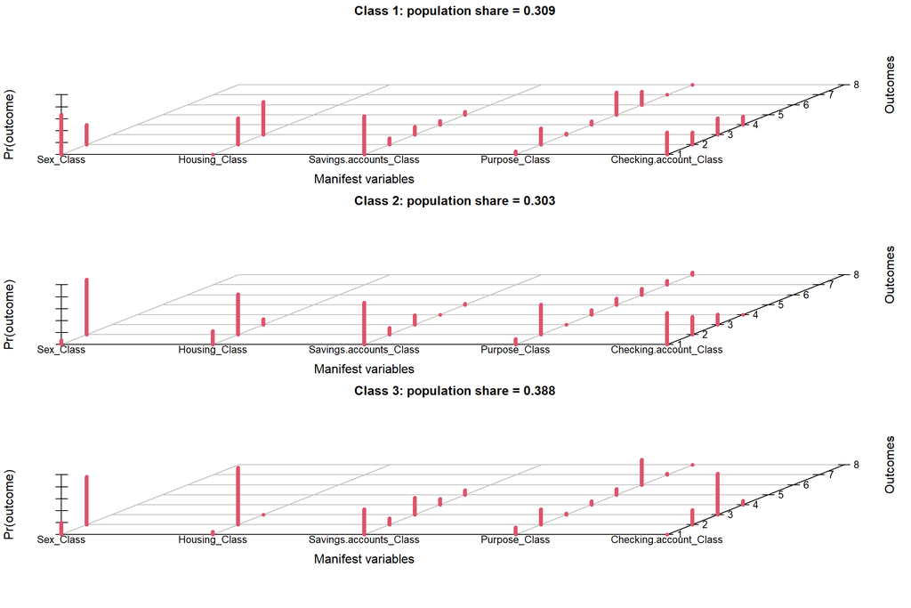

```r
# Storing the probabilities form the train model
LCA.train.object = lca_3class$probs

# Fitting the model with just 1 repetition and using the train model probabilities
lca_2class_.test = poLCA(f, test, nclass=3, nrep=1, tol=.001, verbose=FALSE, graphs=TRUE, probs.start = LCA.train.object )
```

From above we see that: 1. Class proportions are quite similar, thus our model is stable. 2. The Marginal Distribution is different for the Housing Class. 3. The Marginal Distribution is different for the Purpose Class.

Thus overall though there is some variation in the marginal distributions of certain classes the overall proportion of class is quite similar. Thus though this is not a great model but it is good enough to go ahead.

Classes: Sex: 1= Female, 2= Male,

Housing Class: 1 = Free, 2 = Own, 3 = Rented,

Savings.accounts: 1 = Little, 2 = Moderate, 3 = NA, 4 = Quite Rich, 5 = Rich,

Purpose: 1 = Business, 2 = Car, 3 = Domestic/Appliances, 4 = Education, 5 = Furniture, 6 = Radio/TV, 7 = Repairs, 8 = Vacation,

Checking.Account: 1 = Little, 2 = Moderate, 3 = NA, 4 = Rich,

### Analyzing the Classes:

- Naming the classes is quite difficult if one does not have proper understanding of the data. But if exploratory analysis is done properly then naming the classes is not that difficult.
- The most difficult part is to find the number of classes that have not only business sense but also is appropriate from the modelling perspective.